# Travel Package Purchase Prediction Project

### Observation on Product Pitched vs Prod Taken

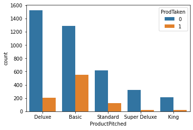

```python
sns.countplot(data=cust1, x="ProductPitched", hue="ProdTaken")
```

Observation

- Customers are likely to purchase Basic Packages more, compared to Deluxe and Standard
- Super Deluxe and Kind have very few customers

### Observation on Product Pitched vs Designation

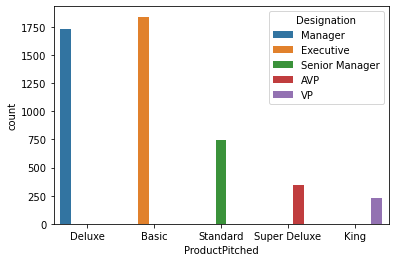

```python
sns.countplot(data=cust1, x="ProductPitched", hue="Designation")
```

Observation

- The targetting of customers (Product Pitched) appears to mapped based on their Designation
- Higher Designations (AVP, VP) are pitched Super Deluxe and King packages
- Top 2 Pitched products are Basic , followed by Deluxe
- For some reason, Standard products are not aggressively pitched

### Observation on Passport Ownership vs ProdTaken

```
ProdTaken     0    1   All
Passport
All        3968  920  4888
1           928  494  1422
0          3040  426  3466
------------------------------------------------------------------------------------------------------------------------
```

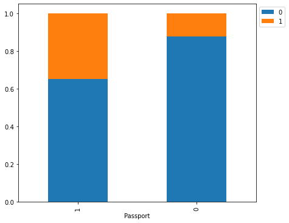

```python
stacked_barplot(cust1, "Passport", "ProdTaken")
```

Observation

- Passport Owners are more likely to purchase a Travel Product compared to customers without passports.

### Observation on CityTier vs ProdTaken

```
ProdTaken     0    1   All
CityTier
All        3968  920  4888
1          2670  520  3190
3          1146  354  1500
2           152   46   198
------------------------------------------------------------------------------------------------------------------------
```

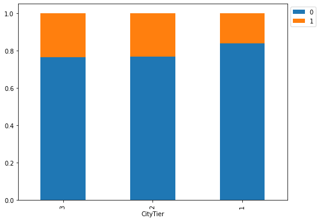

```python
stacked_barplot(cust1, "CityTier", "ProdTaken")
```

Observation

- Customers who live in Tier 2 and Tier 3 Cities , are more likely to purchase a travel product compared to those live in Tier 1

### Observation on Occupation vs Prod Taken

```
ProdTaken          0    1   All
Occupation
All             3968  920  4888
Salaried        1954  414  2368
Small Business  1700  384  2084
Large Business   314  120   434
Free Lancer        0    2     2
------------------------------------------------------------------------------------------------------------------------
```

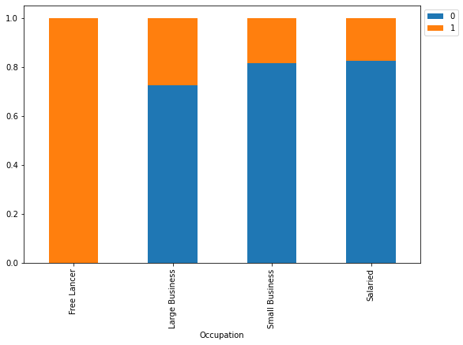

```python
stacked_barplot(cust1, "Occupation", "ProdTaken")
```

Observation

- Freelancers appear to be category with most purchase of Travel Product
- Large Business comes next, followed by Small Business and Salaried class

### Observation on Gender vs Prod Taken

```
ProdTaken     0    1   All
Gender
All        3968  920  4888
Male       2338  578  2916
Female     1500  317  1817
Fe Male     130   25   155
------------------------------------------------------------------------------------------------------------------------
```

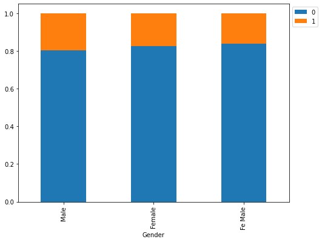

```python
stacked_barplot(cust1, "Gender", "ProdTaken")
```

Observation

- Both Male and Female customers are likely to purchase the travel product, male category has a slight edge.
- Gender values 'Fe Male' and 'Female' to be merged in next section